# The Inequality of Law Enforcement towards the Black Population

Andy Nguyen

2022-11-01

## Abstract

In this report, I will discuss the injustices that many Black people face regarding being sentenced to jail over the last several decades. The data shows that Black people are more likely to be targeted by law enforcement and be sent to jail. Further, I will also show that Black People are targeted more often in certain states of the country than others.

## Introduction

The United States has a mass incarceration and policing problem. Many low-level behaviors are often criminalized, and many people who commit these behaviors and are then incarcerated are often people of color. In particular, Black people are often victims and are unjustifiably arrested. In fact, despite making up 13% of the population, Black men make up 35% of the prison population. Through this data, we are able to bring change. This data can be used by policymakers to help people of color by reforming law enforcement and helping marginalized communities. Further, members of marginalized communities can use this data to help organize their communities and urge people to fight for change. This data set can affect people who work in law enforcement because through this data, reforms towards law enforcement can be made. In turn, new methods can be made to ensure the protection of marginalized groups from law enforcement. Through this data, we can help create a more just and equal future.

## Data Summary

##Growth of the US Jail Population

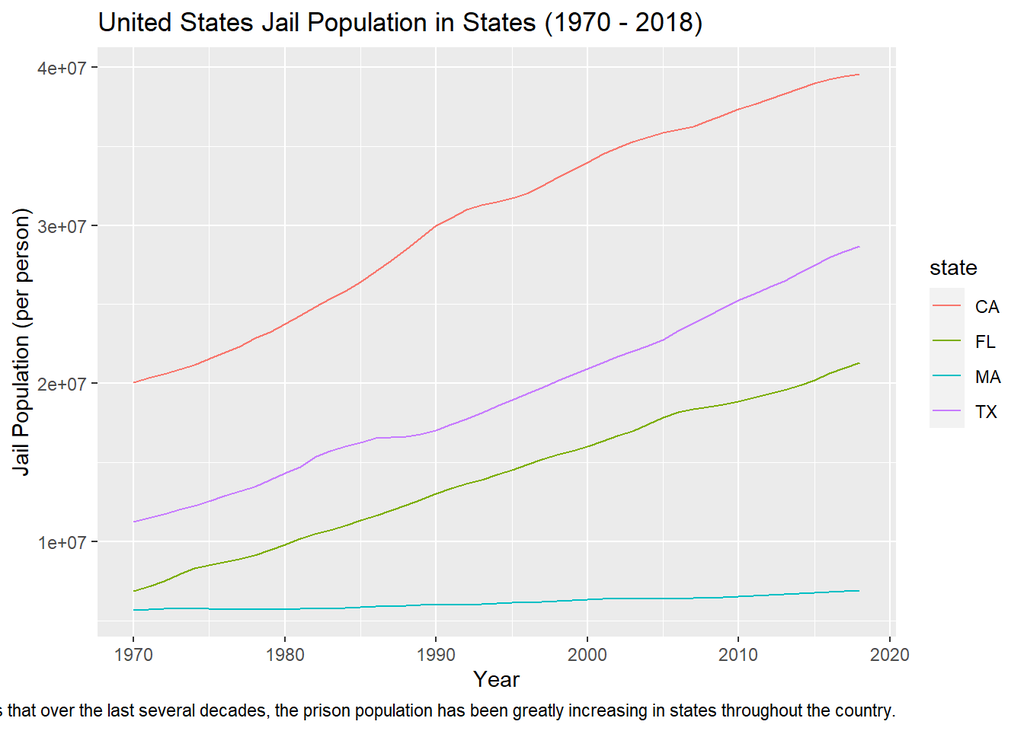

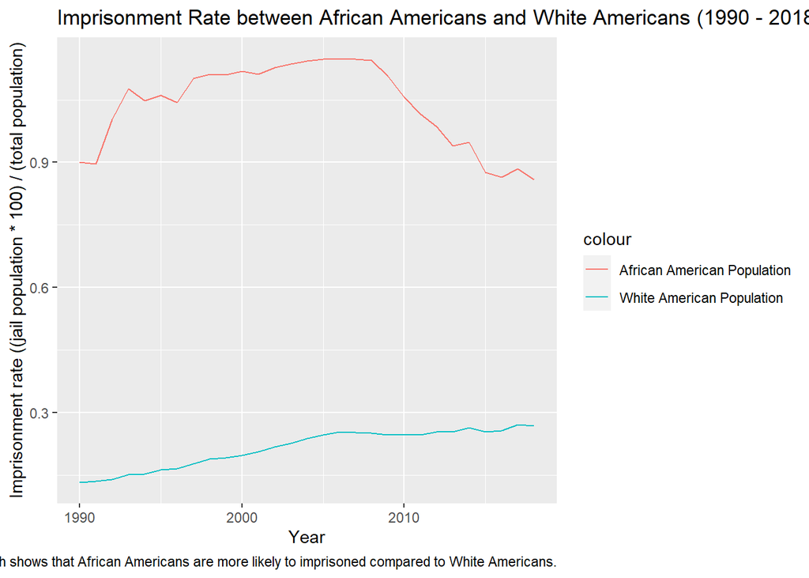

How does the jail rate within the Black community differ from the rate within the White community? To answer this, I divided the jail population by the total population of Black people and White People. The plot shows that within the Black community, black people are more likely to go to jail than white people.

This is concerning because the data shows that despite the population of Black people being lower, they are often punished more and sent to jail. This may suggest that within Black communities, which may often be less fortunate, there is greater policing. Therefore, this may further prove the inequality within this country.

##Map of the jail population rate of Black People

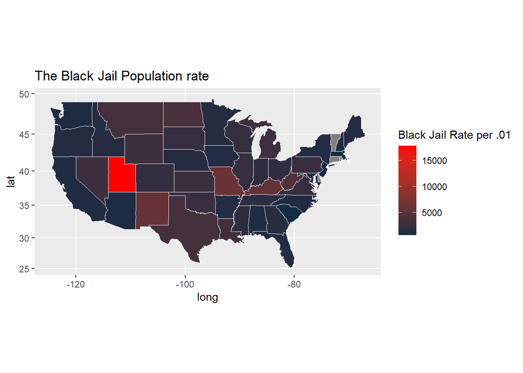